# Eyal Berman - Workshop in Data Science

##### PLEASE SET THE WORKING FOLDER TO THE FOLDER ALL THE FILES ARE IN BEFORE RUNNING THE SCRIPT

```r
skip_computation <- TRUE
list.of.packages <-
  c(
  "ggplot2",
  "dplyr",
  "tidyr",
  "randomForest",
  # "caret",
  "hydroGOF",
  # "ETLUtils",
  "reshape"
  )
  new.packages <-
  list.of.packages[!(list.of.packages %in% installed.packages()[, "Package"])]
  if (length(new.packages)){
    install.packages(new.packages)
  }
  lapply(list.of.packages, require, character.only = TRUE)
```

[output not shown]

```r
  source('ds_project_functions.R')
```

## Loading the data tables

```r
target_data <- read.csv("WorldBank/Millennium_development_goals.csv")
poverty <- read.csv('WorldBank/poverty_and_equity.csv', na.strings = c('..',''))
gender <- read.csv('WorldBank/gender_statistics_female.csv', na.strings = c('..',''))
africa_infra <- read.csv('WorldBank/Africa_Infrastructure.csv', na.strings = c('..',''))
africa_development <- read.csv('WorldBank/africa_development_indicators.csv', na.strings = c('..',''))
health_nutrition <- read.csv('WorldBank/health_and_nutrition.csv', na.strings = c('..',''))
```

## Preparing the tables for training (transpose + fix values)

```r
target_data <- prepare_target_data(target_data)
poverty <- prepare_data_df_to_pivot(poverty)
gender <- prepare_data_df_to_pivot(gender)
africa_infra <- prepare_data_df_to_pivot(africa_infra)
```

```
NAs introduced by coercion
```

```r
africa_infra$Country.Name <- gsub(" ","",gsub("_[A-Z]+","", gsub("\\d.","", (africa_infra$Country.Name))))
health_nutrition <- prepare_data_df_to_pivot(health_nutrition)
africa_development <- prepare_african_development_df(africa_development)
africa_countries <- africa_development$Country.Name %>% unique()
```

## Joining the tables into one big dataset, then filter it to include African countries only

```r
joined_table <- create_joined_table()
```

```
joining factors with different levels, coercing to character vectorjoining factor and character vector, coercing into character vectorjoining factor and character vector, coercing into character vectorjoining factor and character vector, coercing into character vector
```

```r
african_joined_table <- joined_table %>% filter(Country.Name.x %in% africa_countries)
cat(paste("  The size of the initial data is",nrow(african_joined_table),"rows with",ncol(african_joined_table),                                        "features"))
```

```
  The size of the initial data is 1431 rows with 2159 features
```

# Data Preperation

## Remove trivial fields

Remove fields that directly relate to life expectency and death. The list was comprised by running the model and looking at the imporant fields list - then identifying the non-interesting features and removing them

```r
ColumnsToRemove <- c("Mortality","Death.rate","Life.expectancy","Lifetime.risk","Survival.to","Population.ages","Number.of.under.five.deaths","Number.of.infant.deaths","Number.of.neonatal.deaths")
ColumnsToRemoveNumbers <- unique (grep(paste(ColumnsToRemove,collapse="|"),
                        colnames(african_joined_table)))
african_joined_table <- african_joined_table[ ,  -ColumnsToRemoveNumbers]
```

## Remove columns with lots of null values

I’ve tried several options (0.5, 0.9, 0.1), and found out the removing columns with more than 30% null values works best

```r
african_joined_table_with_null <- african_joined_table
african_joined_table <-remove_large_null_columns(african_joined_table, 0.3)
```

## Prepare data for model training

Impute null values, removing rows with no observation data

```r
african_joined_table$Country.Code <- as.factor(african_joined_table$Country.Code)
african_joined_table.imputed <- na.roughfix(african_joined_table)
suppressWarnings(african_joined_table.imputed$Mort_Rate_under_5 <-
  as.numeric(paste(african_joined_table.imputed$Mort_Rate_under_5)))
 # Remove NA rows
african_joined_table.imputed <- african_joined_table.imputed %>% filter(Mort_Rate_under_5 >= 0)
cat(paste("The final size of the data is",nrow(african_joined_table),"rows with",ncol(african_joined_table),                                        "features"))
```

```
The final size of the data is 1431 rows with 569 features
```

## Randomly split the data

Split the data into training (80%) and testing (20%) sets

```r
smp_size <- floor(0.8 * nrow(african_joined_table.imputed))
set.seed(123)
train_ind <- sample(seq_len(nrow(african_joined_table.imputed)), size = smp_size)
train <- african_joined_table.imputed[train_ind, ]
test <- african_joined_table.imputed[-train_ind, ]
```

## Training the model

```r
if (skip_computation) {
    rf.model <- readRDS("./final_rf_model.rds")
} else {
  rf.model <-train_model(300,round(sqrt(length(train))))
}
# saveRDS(rf.model, "./final_rf_model.rds")
```

## Evaluating the model

The most important features, based on the %incMSE are:

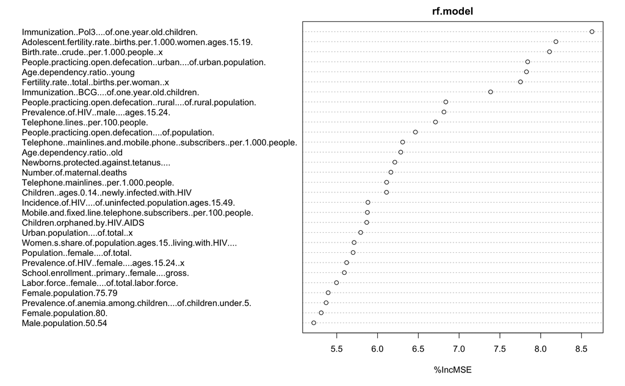

```r
prediction <- predict(rf.model, test)
compare_df <- data.frame(prediction,test$Mort_Rate_under_5, prediction - test$Mort_Rate_under_5)
varImpPlot(rf.model,type=1)
```

*%incMSE = The increase in MSE the would have happened if we permutated the feature. The larger the number, the more the feature contributes to the accuracy of the table

The following shows the IncNodePurity

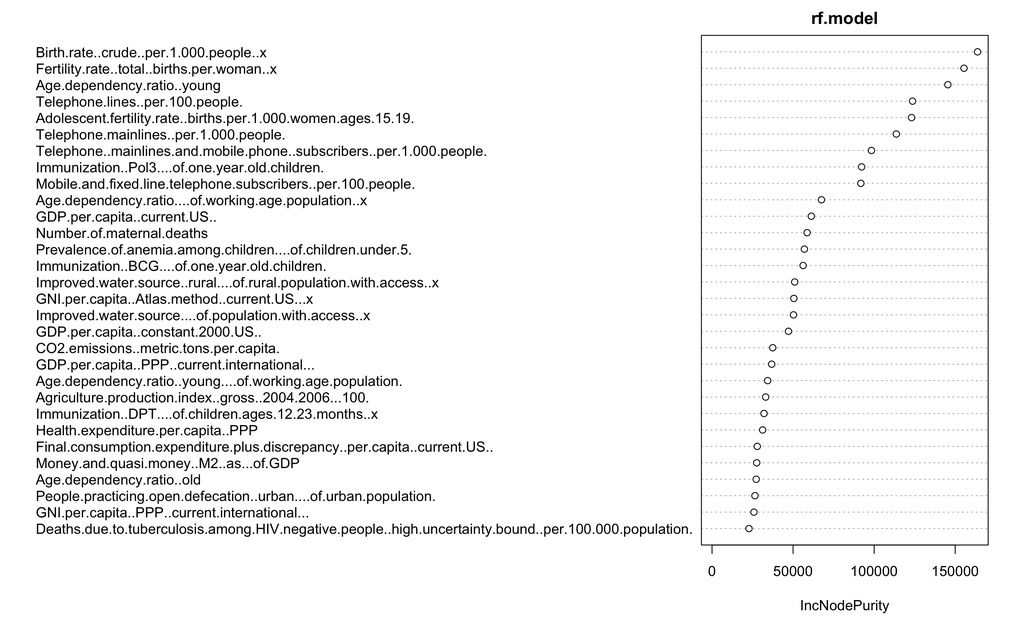

```r
varImpPlot(rf.model,type=2)
```

*IncNodePurity = The average increase in node purity in the tree splits featuring the feature

It is clear that although these 2 metrics measures different things, they both find roughly the same features as the most important ones ##

## rMSE

```r
rmse_prediction <- rmse(compare_df$prediction, compare_df$test.Mort_Rate_under_5)
mean_mortality_rate <- mean(african_joined_table.imputed$Mort_Rate_under_5)
median_mortality_rate <- median(african_joined_table.imputed$Mort_Rate_under_5)
cat(" rMSE is",round(rmse_prediction,2),"\n","mean_mortality_rate is ",round(mean_mortality_rate,2),"\n",
    "median_mortality_rate is ",round(median_mortality_rate,2))
```

```
 rMSE is 9.84
 mean_mortality_rate is  115.24
 median_mortality_rate is  108.75
```

# Fine Tune the Model Parameters

```r
if (skip_computation) {
  print_model_parameter_testing_results()
} else {
train_predict_and_evaluate_model(test,600,100)
train_predict_and_evaluate_model(test,600,30)
train_predict_and_evaluate_model(test,600,20)
train_predict_and_evaluate_model(test,600,10)
train_predict_and_evaluate_model(test,300,24)
train_predict_and_evaluate_model(test,300,30)
train_predict_and_evaluate_model(test,300,20)
train_predict_and_evaluate_model(test,300,10)
train_predict_and_evaluate_model(test,150,24)
train_predict_and_evaluate_model(test,150,30)
train_predict_and_evaluate_model(test,150,20)
train_predict_and_evaluate_model(test,150,10)
train_predict_and_evaluate_model(test,50,24)
train_predict_and_evaluate_model(test,50,30)
train_predict_and_evaluate_model(test,50,20)
train_predict_and_evaluate_model(test,50,10)
}
```

```
  rMSE for 600 trees and 100 features is 10.051
  rMSE for 600 trees and 30 features is 9.689
  rMSE for 600 trees and 20 features is 10.129
  rMSE for 600 trees and 10 features is 10.31
  rMSE for 300 trees and 24 features is 9.837
  rMSE for 300 trees and 30 features is 9.815
  rMSE for 300 trees and 20 features is 10.239
  rMSE for 300 trees and 10 features is 10.259
  rMSE for 150 trees and 24 features is 10.131
  rMSE for 150 trees and 30 features is 9.728
  rMSE for 150 trees and 20 features is 10.16
  rMSE for 150 trees and 10 features is 10.334
  rMSE for 50 trees and 24 features is 10.099
  rMSE for 50 trees and 30 features is 10.431
  rMSE for 50 trees and 20 features is 11.005
  rMSE for 50 trees and 10 features is 11.248
```

# Let’s look at some of the main features

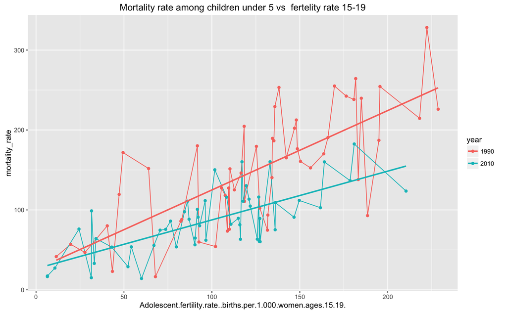

```r
 plot_chart("Adolescent.fertility.rate..births.per.1.000.women.ages.15.19.","fertelity rate 15-19",c(1990,2010))
```

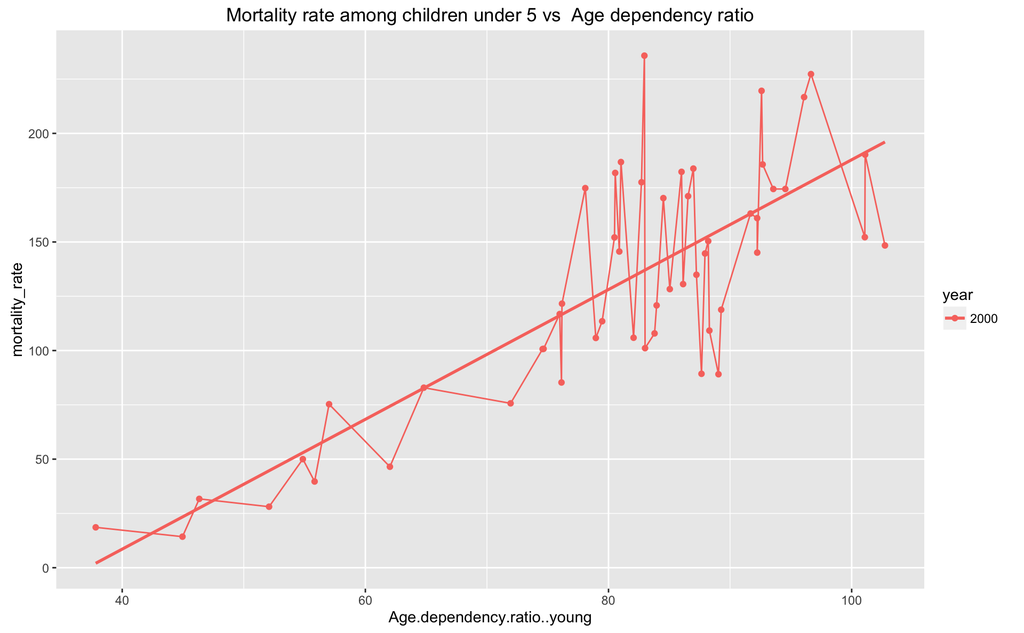

```r
plot_chart("Age.dependency.ratio..young","Age dependency ratio",c(2000))
```

*Age dependency ratio, young, is the ratio of younger dependents–people younger than 15–to the working-age population–those ages 15-64. Data are shown as the proportion of dependents per 100 working-age population. (from the world bank, http://data.worldbank.org/indicator/SP.POP.DPND.YG)

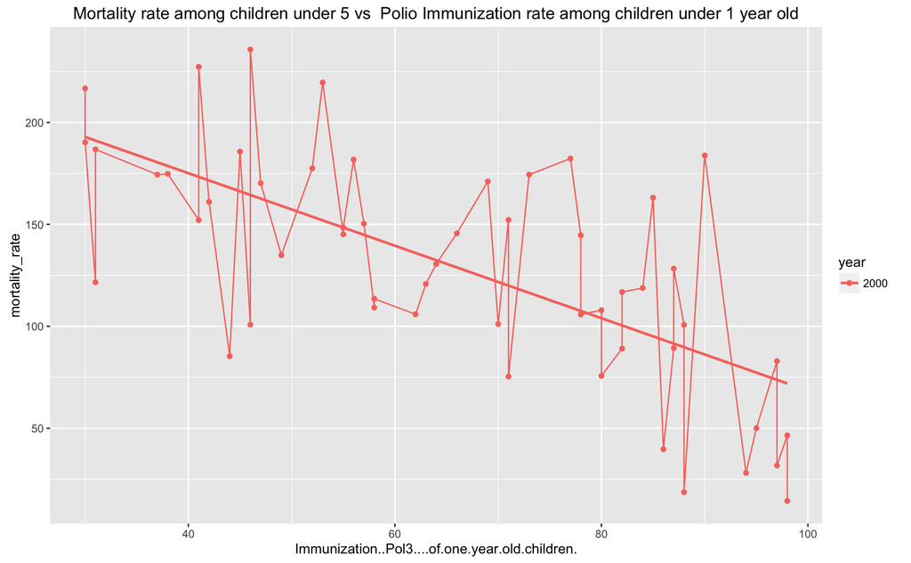

```r
 plot_chart("Immunization..Pol3....of.one.year.old.children.","Polio Immunization rate among children under 1 year old",c(2000))
```

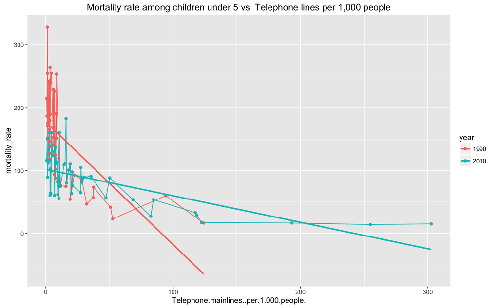

```r
 plot_chart("Telephone.mainlines..per.1.000.people.","Telephone lines per 1,000 people",c(1990,2010))
```

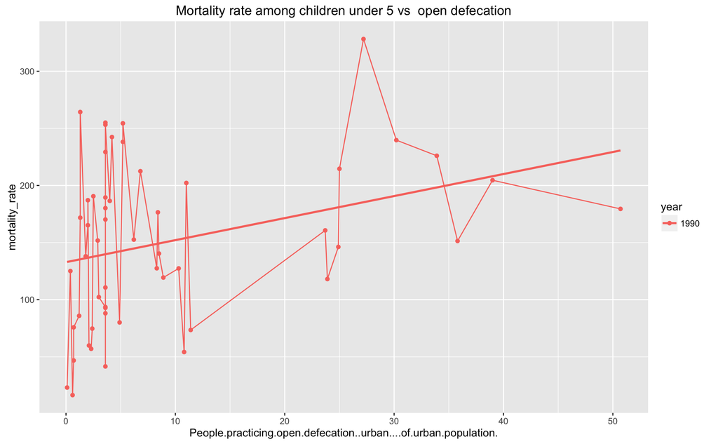

```r
 plot_chart("People.practicing.open.defecation..urban....of.urban.population.","open defecation",c(1990))
```

*People practicing open defecation refers to the percentage of the population defecating in the open, such as in fields, forest, bushes, open bodies of water, on beaches, in other open spaces or disposed of with solid waste. (The World Bank, http://data.worldbank.org/indicator/SH.STA.ODFC.UR.ZS)

[output not shown]

*Newborns protected against tetanus are the percentage of births by women of child-bearing age who are immunized against tetanus. (The World Bank, http://data.worldbank.org/indicator/SH.VAC.TTNS.ZS)

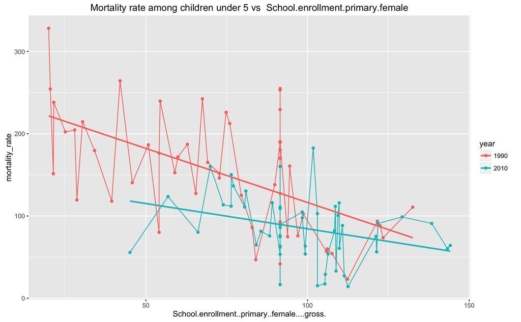

```r
 plot_chart("School.enrollment..primary..female....gross.","School.enrollment.primary.female",c(1990,2010))
```

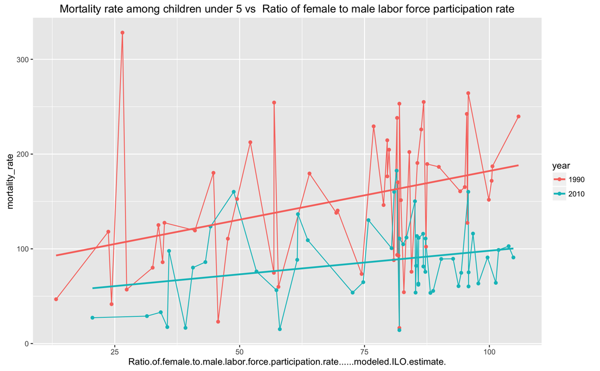

```r
 plot_chart("Ratio.of.female.to.male.labor.force.participation.rate......modeled.ILO.estimate.","Ratio of female to male labor force participation rate",c(1990,2010))
```

- Labor force participation rate is the proportion of the population ages 15 and older that is economically active: all people who supply labor for the production of goods and services during a specified period. (The World Bank, http://data.worldbank.org/indicator/SL.TLF.CACT.FM.ZS)